# Analysis of the flanker experiment data using the Bayesian reaction time and success rate models

Jure Demšar, Erik Štrumbelj and Grega Repovš

2023-09-29

# Introduction

In the Eriksen flanker task participants are presented with an image of an odd number of arrows (usually five or seven). Their task is to indicate the orientation (left or right) of the middle arrow as quickly as possible whilst ignoring the flanking arrows on left and right. There are two types of stimuli in the task: in the **congruent** condition (e.g. ’<<<<<<<’) both the middle arrow and the flanking arrows point in the same direction, whereas in the **incongruent** condition (e.g. ’<<<><<<’) the middle arrow points to the opposite direction of the flanking arrows.

As the participants have to consciously ignore and inhibit the misleading information provided by the flanking arrows in the incongruent condition, the performance in the incongruent condition is robustly worse than in the congruent condition, both in terms of longer reaction times as well as higher proportion of errors. The difference between reaction times and error rates in congruent and incongruent cases is a measure of subject’s ability to focus his or her attention and inhibit distracting stimuli.

In the illustration below we compare reaction times and error rates when solving the flanker task between the control group (healthy subjects) and the test group (subjects suffering from a certain medical condition).

First, we load package **bayes4psy** and package **dplyr** for data wrangling. Second, we load the data and split them into control and test groups. For reaction time analysis we use only data where the response to the stimuli was correct:

```r
# libs
library(bayes4psy)
library(dplyr)

# load data
data <- flanker

# analyse only correct answers, load test and control data
control_rt <- data %>% filter(result == "correct" &
                                 group == "control")

test_rt <- data %>% filter(result == "correct" &
                                 group == "test")
```

```r
# control group subject indexes range is 22..45 cast it to 1..23
# test group indexes are OK
control_rt$subject <- control_rt$subject - 21
```

Now we are ready to fit the Bayesian reaction time model for both groups. The model function requires two parameters – a vector of reaction times $t$ and the vector of subject indexes $s$. Note here that, due to vignette limitations, all fits are built using only one chain, using more chains in parallel is usually more efficient. Also to increase the building speed of vignettes we greatly reduced the amount of iterations, use an appropriate amount of iterations when executing actual analyses!

```r
# prior
uniform_prior <- b_prior(family="uniform", pars=c(0, 3))

# attach priors to relevant parameters
priors <- list(c("mu_m", uniform_prior))

# fit
rt_control_fit <- b_reaction_time(t=control_rt$rt,
                                  s=control_rt$subject,
                                  priors=priors,
                                  chains=1, iter=200, warmup=100)

rt_test_fit <- b_reaction_time(t=test_rt$rt,
                               s=test_rt$subject,
                               priors=priors,
                               chains=1, iter=200, warmup=100)
```

Before we interpret the results, we check MCMC diagnostics and model fit.

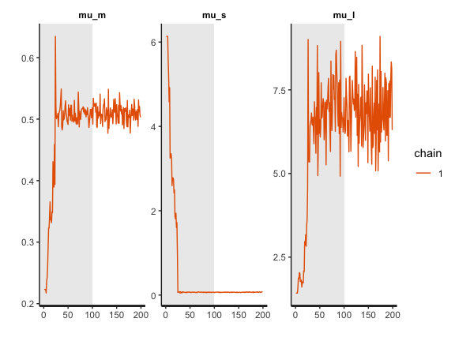

```r
# plot trace
plot_trace(rt_control_fit)
```

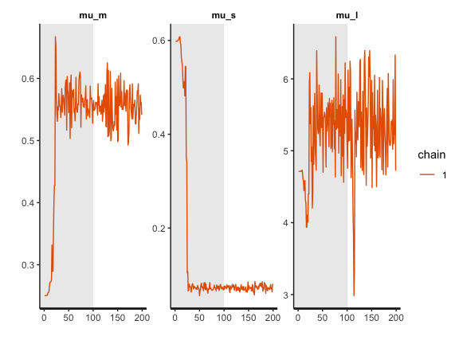

```r
plot_trace(rt_test_fit)
```

```r
# the commands below are commented out for the sake of brevity
#print(rt_control_fit)
#print(rt_test_fit)
```

What is a good-enough effective sample sizes depends on our goal. If we are interested in posterior quantities such as the more extreme percentiles, the effective sample sizes should be 10,000 or higher, if possible. If we are only interested in estimating the mean, 100 effective samples is in most cases enough for a practically negligible Monte Carlo error.

We can increase the effective sample size by increasing the amount of MCMC iterations with the **iter** parameter. In our case we can achieve an effective sample size of 10,000 by setting **iter** to 4000. Because the MCMC diagnostics give us no reason for concern, we can leave the **warmup** parameter at its default value of 1000.

```r
rt_control_fit <- b_reaction_time(t=control_rt$rt,
                                  s=control_rt$subject,
                                  iter=4000)

rt_test_fit <- b_reaction_time(t=test_rt$rt,
                               s=test_rt$subject,
                               iter=4000)
```

Because we did not explicitly define any priors, flat (improper) priors were put on all of the model’s parameters. In some cases, flat priors are a statement that we have no prior knowledge about the experiment results (in some sense). In general, even flat priors can express a preference for a certain region of parameter space. In practice, we will almost always have some prior information and we should incorporate it into the modelling process.

Next, we check whether the model fits the data well by using the **plot** function. If we set the **subjects** parameter to **FALSE**, we will get a less detailed group level fit. The data are visualized as a blue region while the fit is visualized with a black line. In this case the model fits the underlying data well.

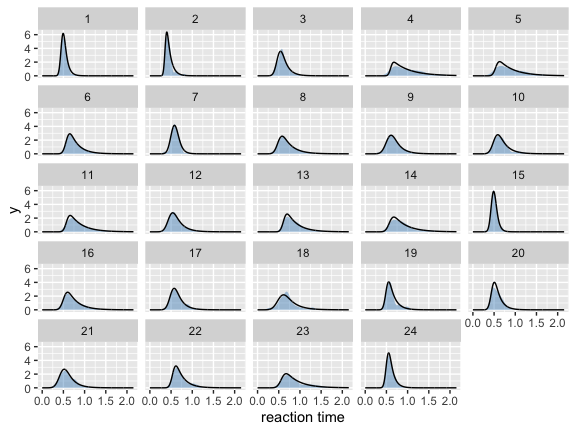

```r
# check fits
plot(rt_control_fit)
```

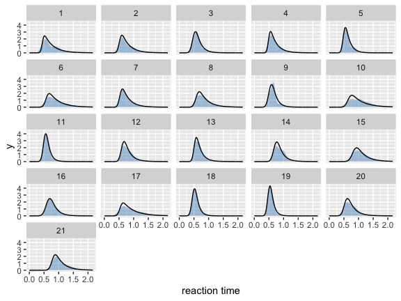

```r
plot(rt_test_fit)
```

We now use the **compare_means** function to compare reaction times between healthy (control) and unhealthy (test) subjects. In the example below we use a rope (region of practical equivalence) interval of 0.01 s, meaning that differences smaller that 1/100 of a second are deemed as equal. The **compare_means** function provides a user friendly output of the comparison and also returns the results in the form of a **data.frame**.

```r
# set rope (region of practical equivalence) interval to +/- 10ms
rope <- 0.01

# which mean is smaller/larger
rt_control_test <- compare_means(rt_control_fit, fit2=rt_test_fit, rope=rope)
```

```
##
## ---------- Group 1 vs Group 2 ----------
## Probabilities:
##   - Group 1 < Group 2: 0.97 +/- 0.01714
##   - Group 1 > Group 2: 0.02 +/- 0.01407
##   - Equal: 0.01 +/- 0.01000
## 95% HDI:
##   - Group 1 - Group 2: [-0.20, -0.02]
```

We can also visualize this difference by using the **plot_means_difference** function. The **plot_means** function is an alternative for comparing **rt_control_fit** and **rt_test_fit** – the function visualizes the parameters that determine the means of each model.

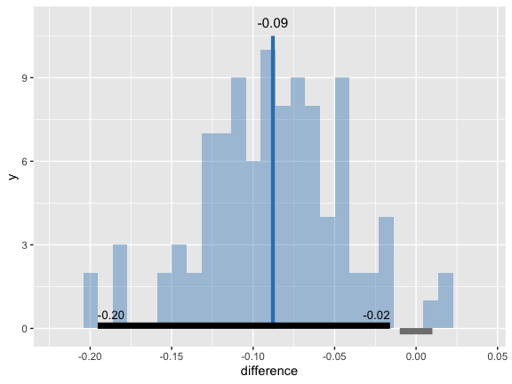

```r
# difference plot
plot_means_difference(rt_control_fit, fit2=rt_test_fit, rope=rope)
```

The graph above visualizes the difference between **rt_control_fit** and **rt_test_fit**. The histogram visualizes the distribution of the difference, vertical blue line denotes the mean, the black band at the bottom marks the 95% HDI interval and the gray band marks the rope interval. Since the whole 95% HDI of difference is negative and lies outside of the rope interval we can conclude that the statement that healthy subjects are faster than unhealthy ones is most likely correct.

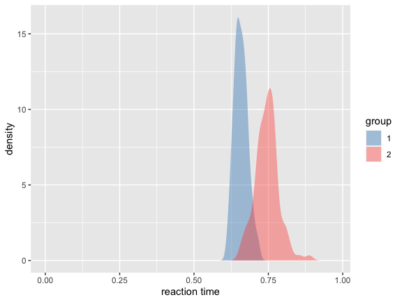

```r
# visual comparsion of mean difference
plot_means(rt_control_fit, fit2=rt_test_fit)
```

Above you can see a visualization of means for **rt_control_fit** and **rt_test_fit**. Group 1 visualizes means for the healthy subjects and group 2 for the unhealthy subjects.

The information about success of subject’s is stored as correct/incorrect. However, the Bayesian success rate model requires binary inputs (0/1) so we have to transform the data. Also, like in the reaction time example, we have to correct the indexes of control group subjects.

```r
# map correct/incorrect/timeout to 1 (success) or 0 (fail)
data$result_numeric <- 0
data[data$result == "correct", ]$result_numeric <- 1

# split to control and test groups
control_sr <- data %>% filter(group == "control")
test_sr <- data %>% filter(group == "test")

# control group subject indexes range is 22..45 cast it to 1..23
# test group indexes are OK
control_sr$subject <- control_sr$subject - 21
```

Since the only prior information about the success rate of participants was the fact that success rate is located between 0 and 1, we used a beta distribution to put a uniform prior on the [0, 1] interval (we put a $\BE(1, 1)$ prior on the $p$ parameter). We execute the model fitting by running the **b_success_rate** function with appropriate input data.

```r
# priors
p_prior <- b_prior(family="beta", pars=c(1, 1))

# attach priors to relevant parameters
priors <- list(c("p", p_prior))

# fit
sr_control_fit <- b_success_rate(r=control_sr$result_numeric,
                                 s=control_sr$subject,
                                 priors=priors,
                                 chains=1, iter=200, warmup=100)
sr_test_fit <- b_success_rate(r=test_sr$result_numeric,
                              s=test_sr$subject,
                              priors=priors,
                              chains=1, iter=200, warmup=100)
```

The process for inspecting Bayesian fits is the same as above. When visually inspecting the quality of the fit (the **plot** function) we can set the **subjects** parameter to **FALSE**, which visualizes the fit on the group level. This offers a quicker, but less detailed method of inspection. Again one of the commands is commented out for the sake of brevity.

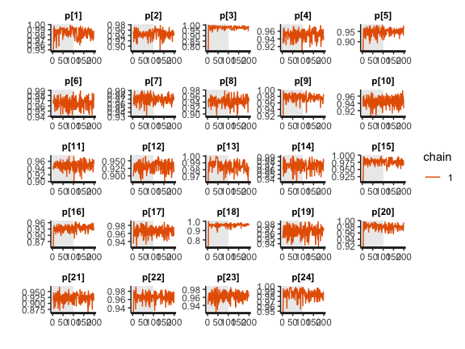

```r
# inspect control group fit
plot_trace(sr_control_fit)
```

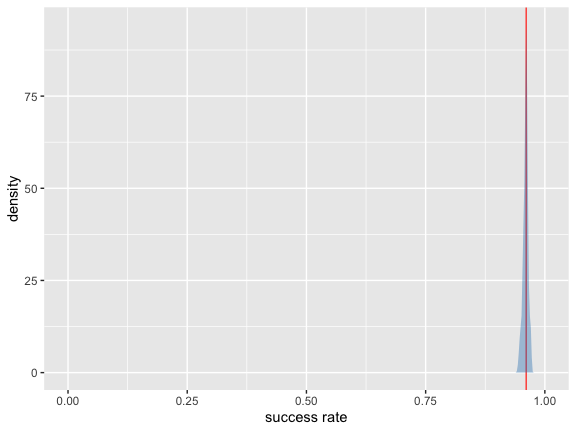

```r
plot(sr_control_fit, subjects=FALSE)
```

```r
print(sr_control_fit)
```

```
## Inference for Stan model: success_rate.
## 1 chains, each with iter=200; warmup=100; thin=1;
## post-warmup draws per chain=100, total post-warmup draws=100.
##
##          mean se_mean    sd    2.5%     25%     50%     75%   97.5% n_eff Rhat
## p0       0.96    0.00  0.01    0.95    0.96    0.96    0.96    0.97    99 0.99
## tau    106.87   12.47 61.04   33.41   59.73   91.52  135.67  267.97    24 0.99
## p[1]     0.98    0.00  0.01    0.96    0.98    0.98    0.99    0.99    46 1.01
## p[2]     0.95    0.00  0.02    0.92    0.94    0.95    0.96    0.97    71 1.00
## p[3]     0.98    0.00  0.01    0.95    0.97    0.98    0.99    0.99    52 1.00
## p[4]     0.95    0.00  0.01    0.92    0.95    0.95    0.96    0.97    77 0.99
## p[5]     0.95    0.00  0.01    0.92    0.94    0.95    0.96    0.97   141 0.99
## p[6]     0.97    0.00  0.01    0.95    0.96    0.97    0.97    0.98   126 1.02
## p[7]     0.97    0.00  0.01    0.96    0.97    0.97    0.98    0.98   104 0.99
## p[8]     0.94    0.00  0.02    0.90    0.93    0.94    0.95    0.97    95 1.01
## p[9]     0.98    0.00  0.01    0.96    0.97    0.98    0.98    0.99    81 0.99
## p[10]    0.95    0.00  0.01    0.92    0.94    0.95    0.96    0.97   131 0.99
## p[11]    0.95    0.00  0.01    0.92    0.94    0.95    0.96    0.97   177 1.02
## p[12]    0.93    0.00  0.02    0.90    0.92    0.94    0.95    0.96    47 1.05
## p[13]    0.98    0.00  0.01    0.97    0.98    0.98    0.99    0.99    39 0.99
## p[14]    0.97    0.00  0.01    0.95    0.96    0.97    0.98    0.99   132 1.01
## p[15]    0.98    0.00  0.01    0.96    0.97    0.98    0.98    0.99    71 0.99
## p[16]    0.94    0.00  0.01    0.91    0.93    0.94    0.95    0.96    70 0.99
## p[17]    0.97    0.00  0.01    0.95    0.96    0.97    0.97    0.98   200 0.99
## p[18]    0.96    0.00  0.01    0.93    0.96    0.96    0.97    0.98    85 1.02
## p[19]    0.97    0.00  0.01    0.94    0.96    0.97    0.97    0.98    89 1.00
## p[20]    0.98    0.00  0.01    0.96    0.97    0.98    0.99    0.99    85 1.01
## p[21]    0.92    0.00  0.02    0.88    0.92    0.93    0.94    0.95    99 0.99
## p[22]    0.97    0.00  0.01    0.95    0.96    0.97    0.98    0.98   137 0.99
## p[23]    0.96    0.00  0.01    0.94    0.96    0.96    0.97    0.98   171 0.99
## p[24]    0.98    0.00  0.01    0.97    0.98    0.98    0.99    1.00    90 1.01
## lp__  -706.57    1.01  4.78 -715.76 -709.83 -705.69 -703.48 -699.14    23 1.06
##
## Samples were drawn using NUTS(diag_e) at Fri Sep 29 14:32:29 2023.
## For each parameter, n_eff is a crude measure of effective sample size,
## and Rhat is the potential scale reduction factor on split chains (at
## convergence, Rhat=1).
```

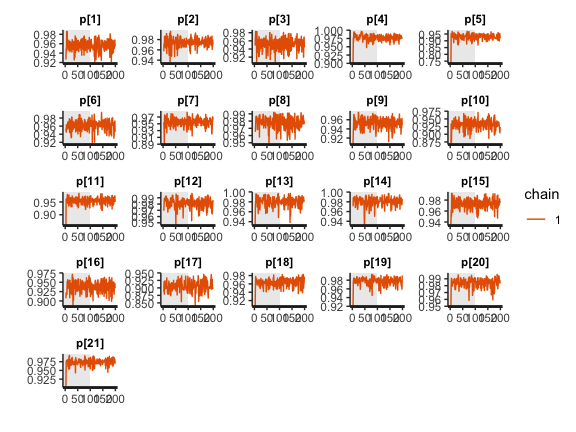

```r
# inspect test group fit
plot_trace(sr_test_fit)
```

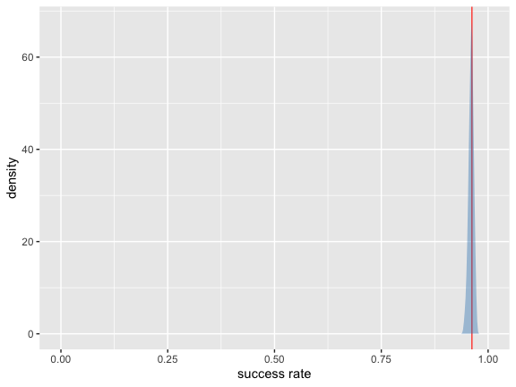

```r
plot(sr_test_fit, subjects=FALSE)
```

```r
#print(sr_test_fit)
```

Since diagnostic functions show no pressing issues and the fits look good we can proceed with the actual comparison between the two fitted models. We will again estimate the difference between two groups with **compare_means**.

```r
# which one is higher
sr_control_test <- compare_means(sr_control_fit, fit2=sr_test_fit)
```

```
##
## ---------- Group 1 vs Group 2 ----------
## Probabilities:
##   - Group 1 < Group 2: 0.57 +/- 0.04976
##   - Group 1 > Group 2: 0.43 +/- 0.04976
## 95% HDI:
##   - Group 1 - Group 2: [-0.02, 0.02]
```

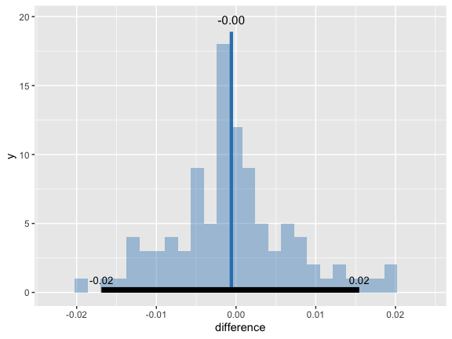

```r
# difference plot
plot_means_difference(sr_control_fit, fit2=sr_test_fit)
```

Above you can see the visualization of the difference between the **sr_control_fit** and the **sr_test_fit**. Histogram visualizes the distribution of the difference, vertical blue line denotes the mean difference and the black band at the bottom marks the 95% HDI interval. Since the 95% HDI of difference includes the value of 0 we cannot claim inequality. If we used a rope interval and the whole rope interval lied in the 95% HDI interval we could claim equality.